# 미국 보스턴 집값 예측

문영훈

2021 12 20

# **연구요약**

- 미국 보스턴 지역의 주택가격에 관한 집값 예측을 위하여,선형회귀모형, 회귀나무모형, 인공신경망 모형, 랜덤포레스트 모형을 사용함
- 따라서, 평균오차값(MSE) 비교를 통하여 모형성능의 우수성을 평가한 결과, 1) 랜덤포레스트 모형, 2) 신경망 모형, 3) 회귀나무모형, 4) 선형회귀모형 순으로 나타남

# 1. 데이터 소개

- 본 연구는 1978년 미국 보스턴 지역의 ⅰ) 주택가격변수, ⅱ) 주택가격에 영향을 미치는 13가지 변수로 이루어진 데이터셋을 분석하고자 함
- 종속변수는 본인소유의 주택가격(MEDV)로 설정하고, 설명변수는 주택가격 변수를 제외한 나머지 변수로 설정하고자 함

```r
Boston <- read.csv('https://raw.githubusercontent.com/blackdew/tensorflow1/master/csv/boston.csv', fileEncoding =  "utf-8")
```

## 1) 주요변수 설명

| 변수 | 변수내용 |
| --- | --- |
| CRIM | 자치시(town) 별 1인당 범죄율 |
| ZN | 25,000 평방피트를 초과하는 거주지역의 비율 |
| INDUS | 비소매상업지역이 점유하고 있는 토지의 비율 |
| CHAS | 찰스강에 대한 더미변수(강의 경계에 위치한 경우는 1, 아니면 0) |
| NOX | 10ppm 당 농축 일산화질소 |
| RM | 주택 1가구당 평균 방의 개수 |
| AGE | 1940년 이전에 건축된 소유주택의 비율 |
| DIS | 5개의 보스턴 직업센터까지의 접근성 지수 |
| RAD | 방사형 도로까지의 접근성 지수 |
| TAX | 10,000 달러 당 재산세율 |
| PTRATIO | 자치시(town)별 학생/교사 비율 |
| Black | 1000(Bk-0.63)^2, 여기서 Bk는 자치시별 흑인의 비율 |
| LSTAT | 모집단의 하위계층의 비율(%) |
| MEDV | 본인 소유의 주택가격(중앙값) (단위: $1,000) |

```r
Boston <- Boston[,-15]
str(Boston)
```

```
## 'data.frame':    506 obs. of  14 variables:
##  $ crim   : num  0.00632 0.02731 0.02729 0.03237 0.06905 ...
##  $ zn     : num  18 0 0 0 0 0 12.5 12.5 12.5 12.5 ...
##  $ indus  : num  2.31 7.07 7.07 2.18 2.18 2.18 7.87 7.87 7.87 7.87 ...
##  $ chas   : int  0 0 0 0 0 0 0 0 0 0 ...
##  $ nox    : num  0.538 0.469 0.469 0.458 0.458 0.458 0.524 0.524 0.524 0.524 ...
##  $ rm     : num  6.58 6.42 7.18 7 7.15 ...
##  $ age    : num  65.2 78.9 61.1 45.8 54.2 58.7 66.6 96.1 100 85.9 ...
##  $ dis    : num  4.09 4.97 4.97 6.06 6.06 ...
##  $ rad    : int  1 2 2 3 3 3 5 5 5 5 ...
##  $ tax    : int  296 242 242 222 222 222 311 311 311 311 ...
##  $ ptratio: num  15.3 17.8 17.8 18.7 18.7 18.7 15.2 15.2 15.2 15.2 ...
##  $ b      : num  397 397 393 395 397 ...
##  $ lstat  : num  4.98 9.14 4.03 2.94 5.33 ...
##  $ medv   : num  24 21.6 34.7 33.4 36.2 28.7 22.9 27.1 16.5 18.9 ...
```

## 2) 변수간 상관관계 분석

- 주택 1가구당 평균 방의 개수가 증가하면 본인소유의 주택가격은 증가하지만, 하위계층의 비율이 증가할수록 본인소유의 주택가격은 감소함

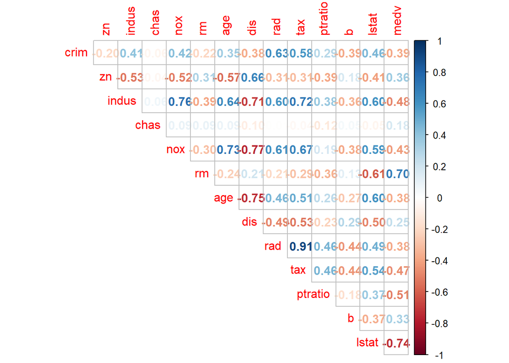

```r
if(!require(corrplot)) install.packages('corrplot')
library(corrplot)

corrplot(cor(Boston), method = "number", type = "upper", diag = FALSE)
```

## 3) 종속변수(본인 소유의 주택가격)와 설명변수 간의 관계

- 종속변수와 양의관계인 설명변수는 black, chas, dis, rm, zn 변수임 □ 종속변수와 음의 관계인 설명변수는 age, crim, indus, lstat, nox, ptratio, rad, tax 변수임

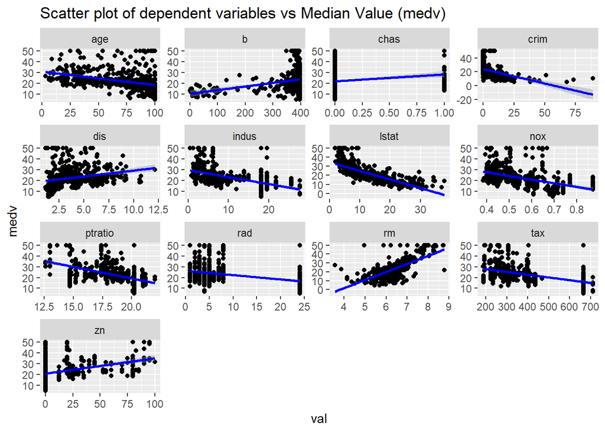

```r
if(!require(ggplot2)) install.packages('ggplot2')
library(ggplot2)
if(!require(tidyr)) install.packages('tidyr')
library(tidyr)


Boston %>%
  gather(key, val, -medv) %>%
  ggplot(aes(x = val, y = medv)) +
  geom_point() +
  stat_smooth(method = "lm", se = TRUE, col = "blue") +
  facet_wrap(~key, scales = "free") +
  theme_gray() +
  ggtitle("Scatter plot of dependent variables vs Median Value (medv)")
```

# 2.예측모형

- 본연구는 선형회귀모형, 회귀나무모형, 인공신경망 모형, 랜덤포레스트 모형을 이용하여 분석함

## 1) 선형회귀모형

- 선형회귀모형의 경우, 원자료 중 70%는 트레이닝 데이터, 30%는 테스트 데이터로 사용하였음

```r
i <- sample(1:nrow(Boston), round(nrow(Boston)*0.7))
Boston.train <- Boston[i,] #70% for training data
Boston.test <- Boston[-i,] #30% for test data
fit.reg <- lm(medv~., data = Boston.train) # 선형회귀모형
summary(fit.reg) # 선형회귀모형 요약
```

```
##
## Call:
## lm(formula = medv ~ ., data = Boston.train)
##
## Residuals:
##      Min       1Q   Median       3Q      Max
## -16.7599  -2.3635  -0.6081   1.7445  26.6324
##
## Coefficients:
##               Estimate Std. Error t value Pr(>|t|)
## (Intercept)  20.277294   5.716989   3.547 0.000445 ***
## crim         -0.150146   0.037365  -4.018 7.22e-05 ***
## zn            0.039629   0.014970   2.647 0.008494 **
## indus         0.047623   0.069627   0.684 0.494460
## chas          1.275969   0.914356   1.395 0.163781
## nox         -12.816623   4.209071  -3.045 0.002508 **
## rm            5.241045   0.469461  11.164  < 2e-16 ***
## age          -0.017343   0.014693  -1.180 0.238689
## dis          -1.262140   0.217717  -5.797 1.54e-08 ***
## rad           0.298014   0.071348   4.177 3.76e-05 ***
## tax          -0.013398   0.004056  -3.303 0.001057 **
## ptratio      -0.844171   0.152224  -5.546 5.89e-08 ***
## b             0.013055   0.002948   4.428 1.28e-05 ***
## lstat        -0.380219   0.061834  -6.149 2.19e-09 ***
## ---
## Signif. codes:  0 '***' 0.001 '**' 0.01 '*' 0.05 '.' 0.1 ' ' 1
##
## Residual standard error: 4.329 on 340 degrees of freedom
## Multiple R-squared:  0.7705, Adjusted R-squared:  0.7617
## F-statistic: 87.79 on 13 and 340 DF,  p-value: < 2.2e-16
```

- 단계적 선택법을 사용하여, 종속변수(부동산 가격)에 미치는 영향이 작은 설명변수를 제거하였음

```r
fit.step.reg <- step(fit.reg, direction = 'both', trace = FALSE) # 단계적 선택법
summary(fit.step.reg) # 조정된 모델 요약
```

```
##
## Call:
## lm(formula = medv ~ crim + zn + chas + nox + rm + dis + rad +
##     tax + ptratio + b + lstat, data = Boston.train)
##
## Residuals:
##      Min       1Q   Median       3Q      Max
## -16.4878  -2.3995  -0.5804   1.7405  26.3230
##
## Coefficients:
##               Estimate Std. Error t value Pr(>|t|)
## (Intercept)  20.633734   5.642859   3.657 0.000296 ***
## crim         -0.149094   0.037289  -3.998 7.82e-05 ***
## zn            0.040847   0.014807   2.759 0.006117 **
## chas          1.308533   0.899426   1.455 0.146627
## nox         -13.207324   3.853966  -3.427 0.000685 ***
## rm            5.079270   0.453438  11.202  < 2e-16 ***
## dis          -1.213772   0.205271  -5.913 8.14e-09 ***
## rad           0.291420   0.069102   4.217 3.17e-05 ***
## tax          -0.012281   0.003648  -3.367 0.000847 ***
## ptratio      -0.843517   0.149798  -5.631 3.74e-08 ***
## b             0.012749   0.002938   4.340 1.88e-05 ***
## lstat        -0.403376   0.057320  -7.037 1.08e-11 ***
## ---
## Signif. codes:  0 '***' 0.001 '**' 0.01 '*' 0.05 '.' 0.1 ' ' 1
##
## Residual standard error: 4.328 on 342 degrees of freedom
## Multiple R-squared:  0.7692, Adjusted R-squared:  0.7618
## F-statistic: 103.6 on 11 and 342 DF,  p-value: < 2.2e-16
```

```r
fit.step.reg$anova # 제거된 변수 보기
```

```
##      Step Df  Deviance Resid. Df Resid. Dev      AIC
## 1         NA        NA       340   6371.072 1051.140
## 2 - indus  1  8.766134       341   6379.838 1049.627
## 3   - age  1 26.165687       342   6406.004 1049.076
```

```r
yhat.reg <- predict(fit.step.reg, newdata = Boston.test, type = 'response') # 데이터 예측, 목표값 예측시 type = 'response'
mean((Boston.test$medv-yhat.reg)^2) # 예측모형의 평균 제곱 오차 mse
```

```
## [1] 33.62878
```

## 2) 회귀나무모형

- 회귀나무모형의 경우, 회귀모형과 동일하게 70%는 트레이닝 데이터, 30%는 테스트 데이터로 사용하였음

```r
if(!require(rpart)) install.packages('rpart')
library(rpart)
set.seed(1234)
i <- sample(1:nrow(Boston), round(nrow(Boston)*0.7))
Boston.train <- Boston[i,] #70% for training data
Boston.test <- Boston[-i,] #30% for test data

my.control <- rpart.control(xval = 10, cp = 0,
                            minsplit = nrow(Boston.train)*0.05)
```

- 종속변수가 연속형변수이므로, 회귀나무 모형을 통하여 분석하였음

```r
fit.tree <- rpart(medv~., data = Boston.train,
                  method = 'anova', control = my.control)

# method = anova 선택 시 회귀나무, class 선택시 분류나무
which.min(fit.tree$cp[,4])
```

```
## 17
## 17
```

```r
fit.tree$cp[17,]
```

```
##           CP       nsplit    rel error       xerror         xstd
##  0.002336343 16.000000000  0.132755321  0.278815553  0.043559036
```

```r
fit.tree$cp[17,1]
```

```
## [1] 0.002336343
```

```r
ii <- which.min(fit.tree$cp[,4])
fit.prune.tree <- prune(fit.tree, cp = fit.tree$cp[ii,1])
```

- 회귀나무 모형 분석을 통하여, 설명변수 중 가장 영향력이 강한 것을 나타내는 뿌리노드의 경우, 지역 내 하위계층의 비율 나타내는것을 알수 있음
- 다음으로, 1) 주택 1가구당 평균 방의 개수, 2) 자치시(town)별 학생/교사 비율 등 순으로 영향을 미치는 것으로 분석할 수 있음

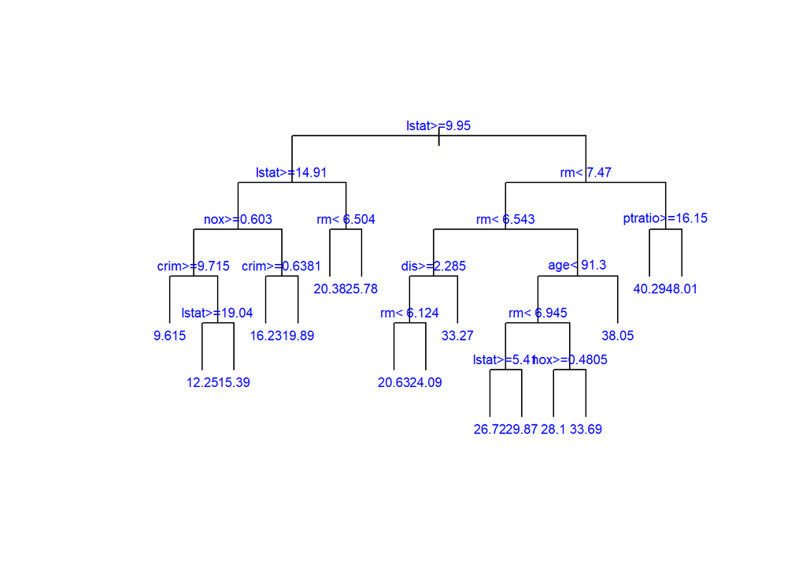

```r
plot(fit.prune.tree, uniform = T, margin = 0.1)
text(fit.prune.tree, col = 'blue', cex = 0.7)
```

```r
yhat.tree <- predict(fit.prune.tree, newdata = Boston.test, type='vector')
```

```r
mean((Boston.test$medv - yhat.tree)^2)
```

```
## [1] 14.27784
```

## 3) 신경망모형

- 신경망모형의 경우, 회귀모형과 동일하게 70%는 트레이닝 데이터, 30%는 테스트 데이터로 사용하였음

```r
if(!require(neuralnet)) install.packages('neuralnet')
library(neuralnet)

Boston2 <- Boston
for(i in
    1:ncol(Boston2)) if (!is.numeric(Boston2[,i])) Boston2[,i]=as.numeric(Boston[,i])
max1 <- apply(Boston2,2,max)
min1 <- apply(Boston2,2,min)

sdat <- scale(Boston2, center = min1, scale = max1-min1)
sdat <- as.data.frame(sdat)

set.seed(1234)
i <- sample(1:nrow(Boston2), round(nrow(Boston2)*0.7))
Boston2.train <- sdat[i,]
Boston2.test<- sdat[-i,]

vname <- names(Boston2.train)
form <- as.formula(paste('medv~', paste(vname[!vname%in%
                                                "medv"], collapse = '+')))

form
```

```
## medv ~ crim + zn + indus + chas + nox + rm + age + dis + rad +
##     tax + ptratio + b + lstat
```

```r
fit.nn <- neuralnet(form, data = Boston2.train, hidden = c(3,2), linear.output = T)
plot(fit.nn)

str(Boston.test)
```

```
## 'data.frame':    152 obs. of  14 variables:
##  $ crim   : num  0.00632 0.02729 0.06905 0.08829 0.14455 ...
##  $ zn     : num  18 0 0 12.5 12.5 12.5 12.5 0 0 0 ...
##  $ indus  : num  2.31 7.07 2.18 7.87 7.87 7.87 7.87 8.14 8.14 8.14 ...
##  $ chas   : int  0 0 0 0 0 0 0 0 0 0 ...
##  $ nox    : num  0.538 0.469 0.458 0.524 0.524 0.524 0.524 0.538 0.538 0.538 ...
##  $ rm     : num  6.58 7.18 7.15 6.01 6.17 ...
##  $ age    : num  65.2 61.1 54.2 66.6 96.1 100 94.3 81.7 98.1 91.7 ...
##  $ dis    : num  4.09 4.97 6.06 5.56 5.95 ...
##  $ rad    : int  1 2 3 5 5 5 5 4 4 4 ...
##  $ tax    : int  296 242 222 311 311 311 311 307 307 307 ...
##  $ ptratio: num  15.3 17.8 18.7 15.2 15.2 15.2 15.2 21 21 21 ...
##  $ b      : num  397 393 397 396 397 ...
##  $ lstat  : num  4.98 4.03 5.33 12.43 19.15 ...
##  $ medv   : num  24 34.7 36.2 22.9 27.1 16.5 15 17.5 13.6 15.2 ...
```

```r
pred <- compute(fit.nn, Boston2.test[,1:13])
summary(pred)
```

```
##            Length Class  Mode
## neurons      3    -none- list
## net.result 152    -none- numeric
```

```r
yhat.nn <- pred$net.result*(max(Boston2$medv)-
  min(Boston2$medv))+min(Boston2$medv) # 역변환
head(cbind(Boston2[i,14], yhat.nn), 50)
```

```
##     [,1]     [,2]
## 1   50.0 29.11083
## 3   21.1 31.90511
## 5    5.0 30.65501
## 7   27.5 21.22453
## 8   13.6 19.13134
## 9   21.7 15.17476
## 11   9.7 19.97827
## 18  23.0 17.73683
## 21  14.2 14.35275
## 23   6.3 16.66148
## 25   7.4 16.71724
## 27  38.7 16.73355
## 32  18.6 17.52337
## 34  28.1 15.46493
```

[output cut: 36 more lines]

```r
Boston2.test$medv<- Boston2.test$medv*(max(Boston2$medv)-min(Boston2$medv))+min(Boston2$medv)
```

- 따라서 예측모형의 평균제곱오차(MSE)는 다음과 같이 약 10.67임

```r
mean((Boston2.test$medv-yhat.nn)^2)
```

```
## [1] 10.66679
```

## 4) 랜덤포레스트

- 랜덤포레스트 모형의 경우, 회귀모형과 동일하게 70%는 트레이닝 데이터, 30%는 테스트 데이터로 사용하였음
- 또한 모형을 적합하는데 ntree = 100, 중간 노드마다 랜덤하게 선택하는 횟수는 5로하고, 변수의 중요도도 계산하고, 결측치는 삭제가 되도록 하여 모형을 적합하였음

```r
if(!require(randomForest)) install.packages('randomForest')
library(randomForest)

set.seed(1234)
i <- sample(1:nrow(Boston), round(nrow(Boston)*0.7))
Boston.train <- Boston[i,]
Boston.test <- Boston[-i,]
fit.rf <- randomForest(medv~., data = Boston.train, ntree = 100, mtry = 5,
                       importance = T, na.action = na.omit)
```

- 랜덤포레스트 분석결과, 회귀 잔차는 12.18로 나왔으며 설명도 또한 약 85%로 이 모형은 성능이 우수하다고 할 수 있다.
- importance 함수를 통해 입력변수의 중요도를 확인한 결과, rm 변수가 가장 높게 나왔으며 그 다음으로 lstat변수가 높게 나왔음

```r
fit.rf
```

```
##
## Call:
##  randomForest(formula = medv ~ ., data = Boston.train, ntree = 100,      mtry = 5, importance = T, na.action = na.omit)
##                Type of random forest: regression
##                      Number of trees: 100
## No. of variables tried at each split: 5
##
##           Mean of squared residuals: 12.18006
##                     % Var explained: 85.42
```

```r
summary(fit.rf)
```

```
##                 Length Class  Mode
## call              7    -none- call
## type              1    -none- character
## predicted       354    -none- numeric
## mse             100    -none- numeric
## rsq             100    -none- numeric
## oob.times       354    -none- numeric
## importance       26    -none- numeric
## importanceSD     13    -none- numeric
## localImportance   0    -none- NULL
## proximity         0    -none- NULL
## ntree             1    -none- numeric
## mtry              1    -none- numeric
## forest           11    -none- list
## coefs             0    -none- NULL
## y               354    -none- numeric
## test              0    -none- NULL
## inbag             0    -none- NULL
## terms             3    terms  call
```

```r
importance(fit.rf, type=1)
```

```
##           %IncMSE
## crim     6.803762
## zn       1.710871
## indus    4.369613
## chas     1.160049
## nox      9.845390
## rm      17.281598
## age      6.369174
## dis      7.715421
## rad      1.818433
## tax      3.771004
## ptratio  6.948059
## b        2.520729
## lstat   12.399530
```

- 따라서 예측모형의 평균제곱오차(MSE)는 다음과 같이 약 9.67임

```r
yhat.tree <- predict(fit.rf, newdata = Boston.test)
mean((Boston.test$medv - yhat.tree)^2)
```

```
## [1] 9.6775
```

# 3.결론

- 선형회귀모형, 회귀나무모형, 인공신경망 모형, 랜덤포레스트 모형의 평균오차값(MSE) 비교를 통하여 모형성능의 우수성을 평가한 결과, 1) 랜덤포레스트 모형, 2) 신경망 모형, 3) 회귀나무모형, 4) 선형회귀모형 순으로 나타남

[output not shown]